# Assingment 7

Surenther

2024-10-10

### Import CSV

```r
# Import CSV
c_data <- read.table(file = "student-survey.csv", header = TRUE, sep = ",")
```

### Plots

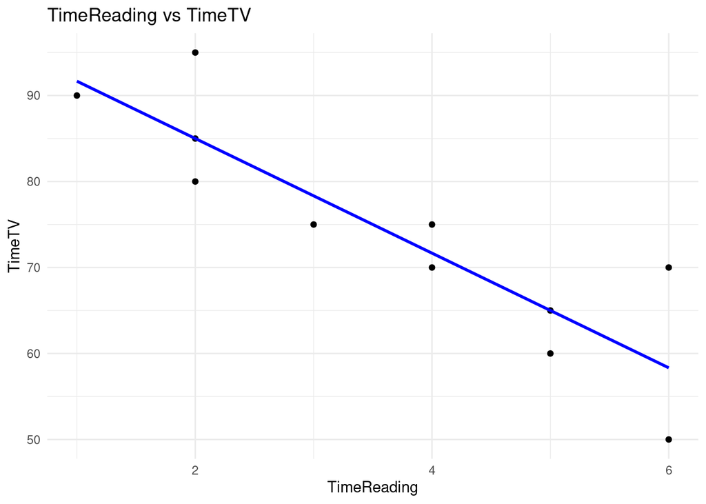

```r
# Load ggplot2
library(ggplot2)

# Plot 1: TimeReading vs TimeTV
ggplot(c_data,aes(x = TimeReading, y = TimeTV)) + geom_point() +
  geom_smooth(method = "lm", se = FALSE, color = "blue") +
  labs(title = "TimeReading vs TimeTV", x = "TimeReading", y = "TimeTV") +
  theme_minimal()
```

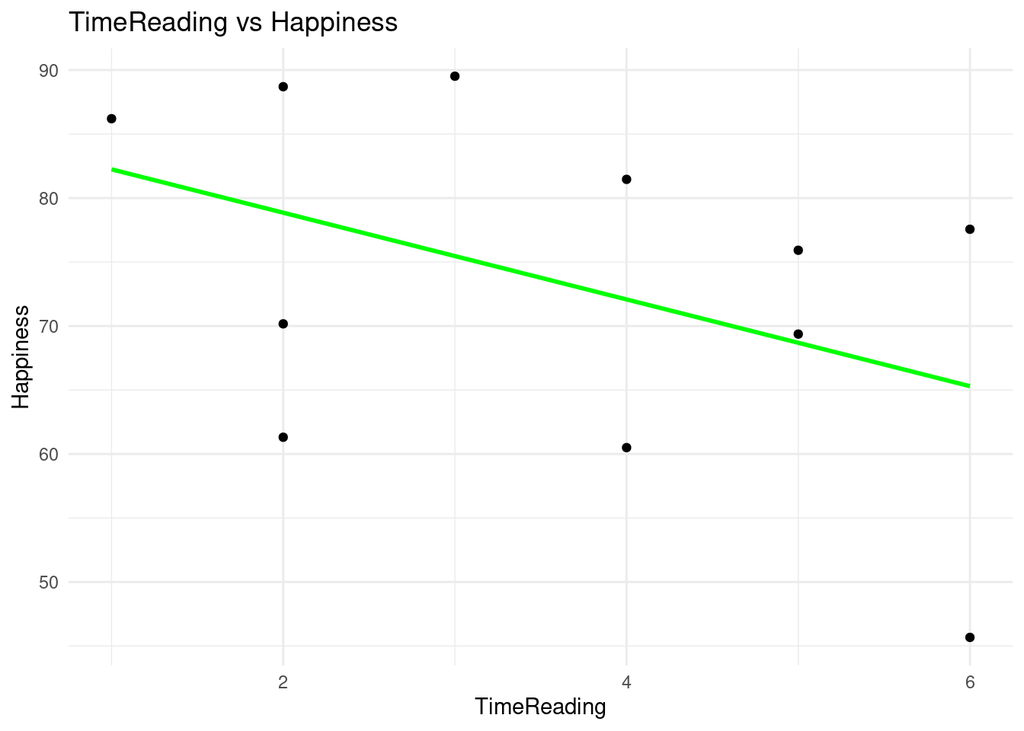

```r
# Plot 2: TimeReading vs Happiness
ggplot(c_data,aes(x = TimeReading, y = Happiness)) + geom_point() +
  geom_smooth(method = "lm", se = FALSE, color = "green") +
  labs(title = "TimeReading vs Happiness", x = "TimeReading", y = "Happiness") +
  theme_minimal()
```

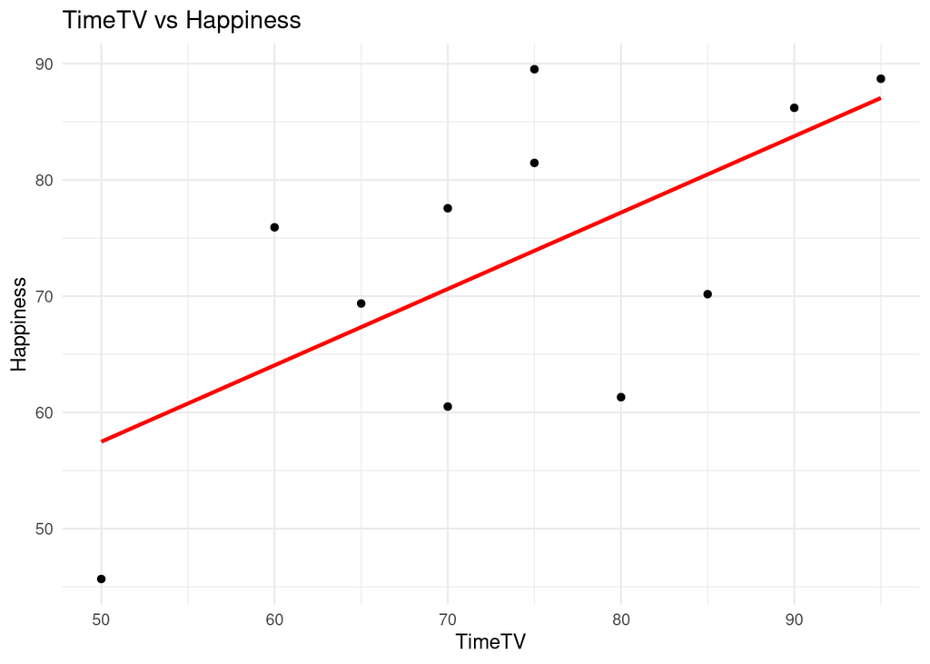

```r
# Plot 3: TimeTV vs Happiness
ggplot(c_data,aes(x = TimeTV, y = Happiness)) + geom_point() +
  geom_smooth(method = "lm", se = FALSE, color = "red") +
  labs(title = "TimeTV vs Happiness", x = "TimeTV", y = "Happiness") +
  theme_minimal()
```

**Findings**  
1. **TimeReading vs TimeTV:** Indicates a Negative relationship, as the more time spent reading decreases the time watching TV.  
2. **TimeReading vs Happiness:** The trend seems mixed, but there might be a weak negative relationship overall.  
3. **TimeTV vs Happiness:** There’s a Positive correlation; as time watching TV increases, happiness tends to increase.

### Covariance Matrix

```r
#Create the correlation matrix
cov_matrix <- cov(data)
print(cov_matrix)
```

```
##             TimeReading    TimeTV Happiness
## TimeReading    3.054545 -20.36364 -10.35009
## TimeTV       -20.363636 174.09091 114.37727
## Happiness    -10.350091 114.37727 185.45142
```

**Findings**  
**Diagonal Values** : These are the variances of the individual variables

- TimeReading : 3.05
- TimeTV : 174.09
- Happiness : 185.45

**Off-diagonal values**: These represent the covariances between pairs of variables  
1. **Covariance between TimeReading and TimeTV** is -20.36, which indicates negative relationship (as reading time increases, TV time decreases)  
2. **Covariance between TimeReading and Happiness** is -10.35, which indicates negative relationship (as reading time increases, happiness decreases)  
3. **Covariance between TimeTV and Happiness** is 114.377, which indicated positive relationship (as TV time increase, Happiness increases as well)

### Correlation Matrix

```r
# Create the correlation matrix
cor_matrix <- cor(data)
print(cor_matrix)
```

```
##             TimeReading     TimeTV  Happiness
## TimeReading   1.0000000 -0.8830677 -0.4348663
## TimeTV       -0.8830677  1.0000000  0.6365560
## Happiness    -0.4348663  0.6365560  1.0000000
```

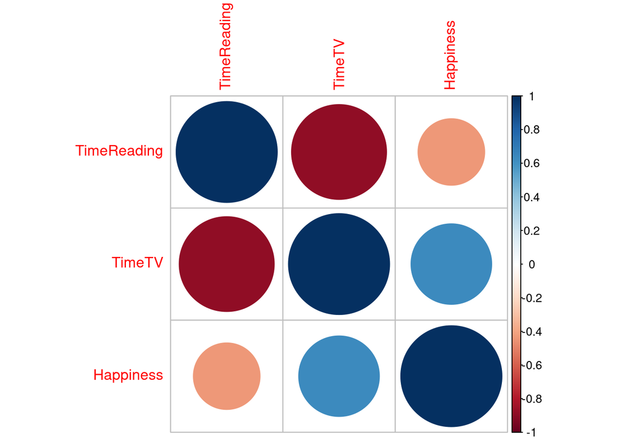

```r
#Visualizing Correlation Matrix
corrplot(cor_matrix)
```

**Findings**  
1. **TimeReading vs TimeTV**: The correlation between time spent reading and watching TV is -0.883, indicating a strong negative relationship. As reading time increases, TV time tends to decrease significantly.  
2. **TimeReading vs Happiness:** The correlation between reading time and happiness is -0.43, suggesting a slight negative relationship. While there is some trend, it is not strongly negative, indicating mixed results.  
3. **TimeTV vs Happiness:** The correlation between TV time and happiness is 0.63, reflecting a moderately positive relationship. More time spent watching TV is associated with an increase in happiness.

### Covarience vs Correlation Matrix

Correlation Matrix is easier to interpret because it gives standardized values between -1 and 1, making it easy to understand the strength and direction of relationships between variables. Covariance Matrix provides raw co-variation, the varying scales make it harder to interpret. Thus, correlation is generally more user-friendly for understanding relationships.

### Correlation Test

```r
# Perform correlation test
cor_test_result <- cor.test(data$TimeReading, data$TimeTV,method="pearson")
print(cor_test_result)
```

```
##
##  Pearson's product-moment correlation
##
## data:  data$TimeReading and data$TimeTV
## t = -5.6457, df = 9, p-value = 0.0003153
## alternative hypothesis: true correlation is not equal to 0
## 95 percent confidence interval:
##  -0.9694145 -0.6021920
## sample estimates:
##        cor
## -0.8830677
```

**Findings**  
1. **Correlation Coefficient (cor = -0.883):** This value indicates a strong negative correlation between TimeReading and TimeTV. As the time spent on reading increases, the time spent watching TV tends to decrease significantly.  
2. **p-value = 0.0003153:** Since the p-value is much smaller than 0.05, the correlation is statistically significant. This means there’s strong evidence that the relationship between TimeReading and TimeTV is not due to random chance.  
3. **Confidence Interval (-0.969 to -0.602):** The 95% confidence interval for the correlation is quite narrow and does not include 0, further confirming a strong negative relationship.

Based on the correlation test, while TimeReading and TimeTV have a strong negative correlation (meaning as reading time increases, TV time decreases), this does not imply causality. Correlation alone shows a relationship but cannot confirm an effect or direction of influence between the variables.